# Analysis.Rmd

Amelia Walsh

2/12/2021

#### Load Libraries

```r
library(dplyr)
```

#### 1. Import the Sequences.csv file.

```r
Sequences = read.csv("../Rentrez/Sequences.csv")
```

#### 2. Count the number of each base pair (A, T, C and G), in each of the three sequences. (Hint: do not include any characters from the header, use the nucleotide sequence only; you MIGHT use gsub(), nchar(), for loops, if/then statements)

```r
#Create new column to store count data
Sequences$TotalBP = 0

#Count number of base pairs for each sequence using a loop
for (i in 1:3){

  #Remove all characters except for A,G,C, and T and count the total
  n = nchar(gsub("[^A|G|C|T]","", Sequences$Sequence[i]))

  #Store data in data frame
  Sequences$TotalBP[i] = n
}

#Display Results
Sequences
```

```
##   X
## 1 1
## 2 2
## 3 3
##                                                                                     Name
## 1 >HQ433692.1 Borrelia burgdorferi strain QLZP1 16S ribosomal RNA gene, partial sequence
## 2   >HQ433694.1 Borrelia burgdorferi strain CS4 16S ribosomal RNA gene, partial sequence
## 3  >HQ433691.1 Borrelia burgdorferi strain GL18 16S ribosomal RNA gene, partial sequence
##                                                                                                                                                                                                                                                                                                          …
## 1 AGCATGCAAGTCAAACGAGATGTAGCAATACATCTAGTGGCGAACGGGTGAGTAACGCGT…
## 2 AGCATGCAAGTCAAACGGGATGTAGCAATACATTCAGTGGCGAACGGGTGAGTAACGCGT…
## 3 AGCATGCAAGTCAAACGAGATGTAGTAATACATCTAGTGGCGAACGGGTGAGTAACGCGT…
##   TotalBP
## 1     481
## 2     481
## 3     481
```

#### 3. Print out each sequence.

```r
print(Sequences$Sequence)
```

```
## [1] "AGCATGCAAGTCAAACGAGATGTAGCAATACATCTAGTGGCGAACGGGTGAGTAACGCGT…"
## [2] "AGCATGCAAGTCAAACGGGATGTAGCAATACATTCAGTGGCGAACGGGTGAGTAACGCGT…"
## [3] "AGCATGCAAGTCAAACGAGATGTAGTAATACATCTAGTGGCGAACGGGTGAGTAACGCGT…"
```

#### 4. Print out the number of each nucleotide as a table for each of the three sequences.

```r
#Create data frames to store data
Adenine = 0
Guanine = 0
Cytosine = 0
Thymine = 0

#Count number of each base pair for each sequence using a loop
for (i in 1:3){

  #Remove all characters except for A and count the number of A for each sequence
  a = nchar(gsub("[^A]","",Sequences$Sequence[i]))
  Adenine[i] = a

  #Remove all characters except for G and count the number of G for each sequence
  g = nchar(gsub("[^G]","",Sequences$Sequence[i]))
  Guanine[i] = g

  #Remove all characters except for C and count the number of C for each sequence
  c = nchar(gsub("[^C]","",Sequences$Sequence[i]))
  Cytosine[i] = c

  #Remove all characters except for T and count the number of T for each sequence
  t = nchar(gsub("[^T]","",Sequences$Sequence[i]))
  Thymine[i] = t
}
#Display Results
(DT <- data.frame(
Adenine = Adenine,
Guanine = Guanine,
Thymine = Thymine,
Cytosine = Cytosine,
Sequence = Sequences$Name
))
```

```
##   Adenine Guanine Thymine Cytosine
## 1     154     131     114       82
## 2     155     131     114       81
## 3     154     131     115       81
##                                                                                 Sequence
## 1 >HQ433692.1 Borrelia burgdorferi strain QLZP1 16S ribosomal RNA gene, partial sequence
## 2   >HQ433694.1 Borrelia burgdorferi strain CS4 16S ribosomal RNA gene, partial sequence
## 3  >HQ433691.1 Borrelia burgdorferi strain GL18 16S ribosomal RNA gene, partial sequence
```

#### 5. Include an image of a bacteria from the internet, and a link to the Wikipedia page about Borrelia burgdorferi

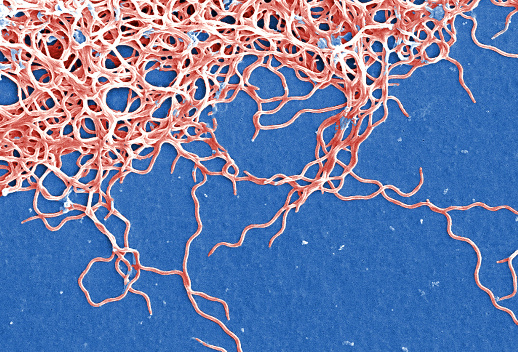

Borrelia burgdorferi

[Link to Borrelia burgdorferi Wikipedia Page](https://en.wikipedia.org/wiki/Borrelia_burgdorferi)

```r
DT$TotalBP = Sequences$TotalBP
DT %>% summarise(GC_Content = (DT$Guanine + DT$Cytosine)/DT$TotalBP, Sequence_Name = DT$Sequence)
```

```
##   GC_Content
## 1  0.4428274
## 2  0.4407484
## 3  0.4407484
##                                                                            Sequence_Name
## 1 >HQ433692.1 Borrelia burgdorferi strain QLZP1 16S ribosomal RNA gene, partial sequence
## 2   >HQ433694.1 Borrelia burgdorferi strain CS4 16S ribosomal RNA gene, partial sequence
## 3  >HQ433691.1 Borrelia burgdorferi strain GL18 16S ribosomal RNA gene, partial sequence
```

Using what you have learned, make a new script called COVIDgenome.R that will download the SARS-CoV-2 reference genome from Genbank. Use the accession NC_045512.2 The Spike glucoprotein (aka S protein) plays an important role in infection, and therefore it determines the virulence of the strain and it’s a target for vaccines and other therapeutic drugs. The S protein starts at bp position 21,563 and ends at position 25,384 Use regular expressions in R to isolate the S protein from the genome you downloaded Open a BLAST search in your web browser. Manually paste in the sequence and run the BLAST search with default parameters. It may take a few minutes for the search to run. After it’s finished, look at the tabs Descriptions, Graphic Summary, and Alignments. Would you say this gene is highly conserved or evolving rapidly? Why? Explain this in a comment at the end of your second script. To submit this assignment: upload your files to onQ and include the github link to your repository as a comment.